# A parametric comparison of means

Dr Juan H Klopper

## Preamble

The time has come for us to do some real inferential statistics. In this tutorial we will look at comparing the means for a numerical variable between two or more groups. It is important to understand that the groups are made up of splitting the subjects of a research project by the sample space of one of the categorical variables in the dataset. Note that this *splitting into groups* can also be done by a numerical variable, but this variable will have to be converted to a categorical variable. An example might be *age*. We can groups all patients younger than $60$ years of age as belonging to a group called *young* and everyone else belonging to a group called *not young*. This necessitates a new variable in which the sample space will be these two new data point values.

We will stick to the more common case of using one of the categorical variables to create two or more groups. It is the difference in means for a numerical variable that is our interest in this chapter.

The most common test to compare the means for a numerical variable between two groups is Students’ *t* test. When comparing more than two groups, the most common test is analysis of variance (ANOVA).

All the tests in this chapter are examples of parametric tests. Parametric tests are based on assumptions made of the data. These assumptions must be met before we can actually use these test. Fortunately, this is so in most cases. In the next chapter, we will actually look at these assumptions and learn about specific statistical tests associated with these assumptions. If these tests show that the assumptions do not hold, we cannot use the common parametric tests shown in this chapter. Instead, we will use non-parametric test, which will be the subject of the following chapter.

## Student’s *t* test

As quintessential example of a parametric comparison of two means, we will conduct Student’s *t* test. This tests compares the means of numerical variable between two groups. It is one of the most common tests in inferential statistics.

Let’s then consider our original dataset that we have been using all along. We used the `setwd(getwd())` statement at the beginning of this R markdown file and saved it in the same directory or folder as the spreadsheet file that we will use.

```r
library(dplyr)
library(car)  # For Levene's test
```

```r
df <- read.csv("ProjectData.csv")  # Using the built-in read.csv function
```

We remember that there are two values in the sample space of the `Group` variable. We can use the `table()` function to count the occurrences of each.

```r
table(df$Group)  # Count the occurences of each of the sample space values
```

```
##
##   I  II
## 251 249
```

To conduct Student’s *t* test, we will use the `t.test()` function. We need to pass two lists containing the numerical variable under consideration as arguments. There are a few ways to go about this. Below, we create two list objects to achieve this. Let’s compare the ages between the two groups. We used appropriately named computer variables and the `filter()` and `select()` function from the `dplyr` library to do this. The added `pull()` function converts the extracted single column tibble object as a vector of values.

```r
# Selecting only the Age column values but splitting those by the sample space
# of the Group column
group_I_age <- pull(df %>% filter(Group == "I") %>%
  select(Age))  # Only patients that have a data point value of I in the Group column
group_II_age <- pull(df %>% filter(Group == "II") %>%
  select(Age))  # Only patients that have a data point value of II in the Group column
```

Now for the simple *t* test. We pass the two vectors (lists of age values) as arguments.

```r
t.test(group_I_age,  # Age values of patients in group I
       group_II_age,  # Age values of patients in group II
       var.equal = TRUE)  # Stating that we are assuming equal variances
```

```
##
##  Two Sample t-test
##
## data:  group_I_age and group_II_age
## t = 0.557, df = 498, p-value = 0.5778
## alternative hypothesis: true difference in means is not equal to 0
## 95 percent confidence interval:
##  -1.478460  2.648431
## sample estimates:
## mean of x mean of y
##  58.66932  58.08434
```

We note a *t statistic* of $0.557$, a degrees of freedom (DOF) values of $498$,, and a *p* value of $0.58$ (rounded). We also note a confidence interval around the differences in the two means (more on this later) and the two actual means. In between there is a statement about an alternative hypothesis.

The *p* value is more than $0.05$ and we would state that there is not a significant different in age between patients in group I and group II. The two mean values are also easy to interpret.

We need to spend some time on the other information, though.

## Hypothesis testing

The goal of inferential statistics is infer the results from a sample to a larger population. To do this, we need to formulate a research question. In our simple case this would be: *“Is there a difference in age between patients in the two groups?”* This is indeed a proper question, since we can translate it back to the variable for which we have collected data point values in our sample of patients. We have a numerical variable `Age` and a categorical variable `Group`. We create two groups from the latter as it has a sample space of two elements, i.e. `I` and `II`.

As good scientists we set a **null hypothesis**, which we accept as the truth unless gathered evidence shows the contrary. This null hypothesis always assume that our research question returns a *not true* value. In this case: *“No, there is no difference between the ages of the two groups.”* More specifically, we state that the difference in means is $0$.

Now, we need to specify an **alternative hypothesis**. This is the hypothesis that we **accept** when evidence shows that we can **reject** the null hypothesis. This is what happens when we state that there is a *statistically significant difference between the (mean) ages of the two groups*.

This decision is based on a *p* value and an arbitrary cut-off, known as the $\alpha$ value. It is customary to set this as $0.05$, such that a *p* value of less than $0.05$ leads us to reject our null hypothesis and accept our alternative hypothesis. When the *p* value is not less than $0.05$, we fail to reject our null hypothesis and state that there is no significant different between the (mean) ages of the two groups.

## Degrees of freedom and the *t* distribution

The DOF value in a *t* test is simply the the sample size minus two (because we have two groups). Since we had a sample size of $500$, we have a DOF value of $498$.

In the previous chapter we looked at the *t* distribution. This is a sampling distribution and *simulates* all the possible differences in means that we could find if we could do our research over and over again. Since we cannot, the *t* distribution uses the DOF value to create a theoretical distribution. Let’s look at this distribution with a DOF of $498$.

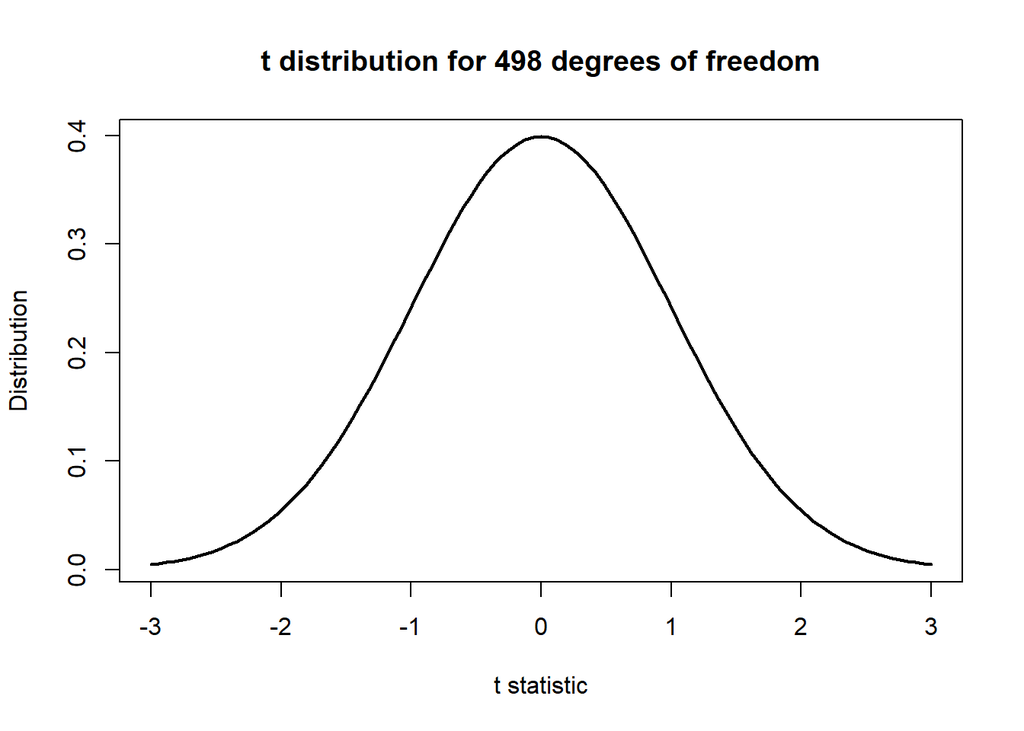

```r
curve(dt(x, df = 498),
      from = -3, to = 3,
      lwd = 2,
      main = "t distribution for 498 degrees of freedom",
      ylab = "Distribution",
      xlab = "t statistic")
```

The difference in means for our two set of ages was $0.585$. This is converted to a *t* statistic with the use of a pooled variance for the whole sample. The *t* distribution above is a sampling distribution of all possible *t* statistic values (based only on the DOF value). As an aside, if we knew the standard deviation of a variable in the whole distribution, we would not need the *t* distribution, but would instead use the *z* distribution (from the standard normal distribution).

The *t* statistic was $0.557$. Let’s place this on our plot.

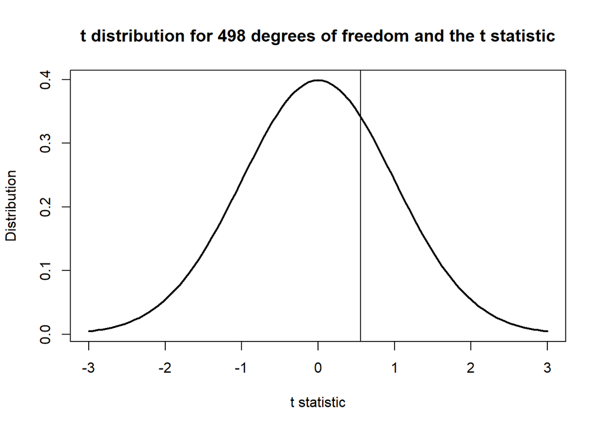

```r
curve(dt(x, df = 498),
      from = -3, to = 3,
      lwd = 2,
      main = "t distribution for 498 degrees of freedom and the t statistic",
      ylab = "Distribution",
      xlab = "t statistic")
abline(v = 0.557)
```

Of particular importance here, is our null and alternative hypothesis. We stated a null hypothesis of no difference in ages and an alternative hypothesis of a difference. We did not state that group I patients will be older or younger than those in group II. The difference in means would also be either positive or negative based in which mean we subtracted from which mean. This is termed *a two-tailed alternative hypothesis* and is the proper standard in hypothesis testing.

This all means that we have to replicate the *t* statistic on the other side of the graph.

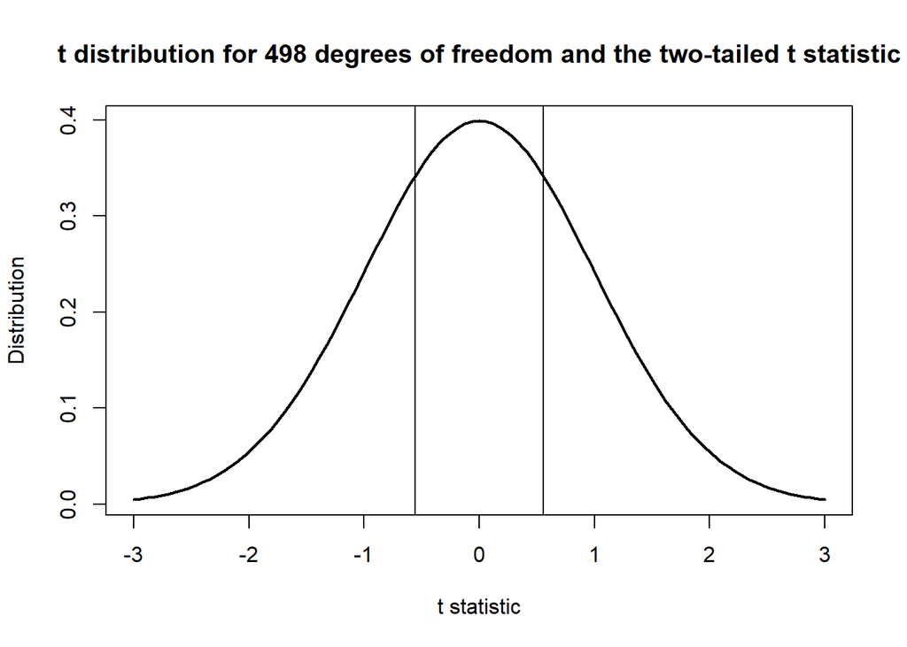

```r
curve(dt(x, df = 498),
      from = -3, to = 3,
      lwd = 2,
      main = "t distribution for 498 degrees of freedom and the two-tailed t statistic",
      ylab = "Distribution",
      xlab = "t statistic")
abline(v = 0.557)
abline(v = -0.557)
```

The area under the *t* distribution curve (for whatever DOF value) is $1$. The areas under the curve from negative infinity to our left-hand side *t* statistic and from our right-hand side *t* statistic to positive infinity is calculated. This is the two-tailed *p* value.

If we could reasonably convince our audience that one mean would be higher than the other, we could calculate a one-tailed *p* value. Depending on how we stated this (which group was higher), we would either have the area under the curve to the left or right of the *t* statistic as our ultimate *p* value.

As a bit of fun, we can add two vertical lines that would represent an area of $0.05$ (that is $0.025$ on either side). For $498$ DOF, those *t* statistics (known as *critical values*) would be about $-1.96$ and $1.96$.

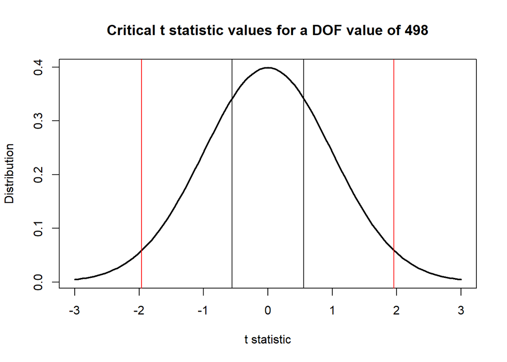

```r
curve(dt(x, df = 498),
      from = -3, to = 3,
      lwd = 2,
      main = "Critical t statistic values for a DOF value of 498",
      ylab = "Distribution",
      xlab = "t statistic")
abline(v = 0.557)
abline(v = -0.557)
abline(v = -1.96,
       col = "red")
abline(v = 1.96,
       col = "red")
```

It is now clear that our *t* statistic has an area under the curve way more than the critical *t* statistic. This represents an $\alpha$ value of $0.05$.

## The confidence interval

A confidence interval in this setting refers to the difference in means. Remember that we have taken samples from population. Five-hundred of them. Through hypothesis testing, we actually want to know if these are two different populations (Groups I and II might have been chosen such that we suspect some differences, i.e. receiving a different treatment).

Since we are dealing with inferential statistics, we want to infer this difference in means to the underlying populations. Because we only have a sample of each, we know that this difference will not be accurate. We can *take a guess* at where the difference in means would lie.

To do this we set a confidence level, typically $95$%. This will given us a symmetric value below and above our difference in mean. A confidence interval. This interval does not state that we are $95$% confident that the true difference in means falls between the two values! It means that of we repeated the study $100$ times (each time will have difference interval values), that in $95$% of them, the true population difference would fall between the interval values. We don’t now whether our current intervals are one of the correct $95$% or the incorrect $5$%>

To calculate the confidence interval for the difference in means, we construct a _t_distribution around a mean difference of our current mean difference (for a given DOF value) and find the values which will represent $2.5$% of the curve on either side of the middle.

The `t.test()` function does this for us. In our example, comparing the ages of patients in groups I and II, the `t.test()` function results shows lower and upper bounds for the $95$% confidence interval as $-1.48$ and $2.65$ (rounded). The mean of these two values is $0.58$. The is also the actual difference in means between the two groups,as it should be. The confidence intervals fall symmetrically around the mean difference.

We would interpret this as a non-statistically significant difference and also have some difference range that we could infer on our population. We note, though, that we cannot be sure that this particular study is on of the $95$% of studies we could do (all with different confidence intervals) that contain the actual difference between the two populations.

## Comparing the means of two groups with unequal variances

Student’s *t* test as was used above assumes that there is a near equal variance for the numerical variable in the two groups. Let’s take a look at the variances in age.

```r
df %>% group_by(Group) %>%
  summarise(VAR = var(Age))
```

```
## # A tibble: 2 x 2
##   Group   VAR
##   <fct> <dbl>
## 1 I      133.
## 2 II     143.
```

For the units in which age in measured (years and in the case of variance $\text{years}^2$), this is not a big difference.

There is a test that can investigate this, though, and it is Levene’s test.

The `car` library contains the `leveneTest()` function. We can use a formula as below to investigate the differences in variances. The formula uses a tilde symbol and is pretty intuitive.

```r
leveneTest(df$Age ~ df$Group)
```

```
## Levene's Test for Homogeneity of Variance (center = median)
##        Df F value Pr(>F)
## group   1  0.6727 0.4125
##       498
```

Since our *p* value for this test was not less than $0.05$, we do not reject the null hypothesis which is that there is no difference in the variances.

If there was, we would simply use the `t.test()` function, but use the keyword argument and value `var.equal = FALSE`.

## Paired samples

Our dataset does not contain statistical variables that we might use for paired samples. Examples would have been the `CRP` variable for instance. We might have measured this variable before and after an intervention. When this is done, there is a dependence between the two sets of variable that we could investigate. A *t* test comparing the means of the before and after values. Be careful, as we are no longer creating two groups by way of a categorical variable. To do this, we might calculate the difference between the before and after values and investigate the differences in means between these differences for two groups.

Here, though, we are looking at matched pairs of value. In this case we would still use the `t.test()` function, but use the `paired = TRUE` keyword argument.

## Comparing more than two means

If we want to compare more than two means, we have to use analysis of variance (ANOVA). This is a fundamental test using the *F* distribution. It is actually the basis for many statistical analysis. here we will simply use it for comparing the means of more than two groups.

Since we have five elements in the `Survey` categorical variable, let’s compare the mean ages between all five groups. First, we make sure than the `Survey` statistical variable is seen as categorical. The `factor()` function achieves this. We also specify the actual elements in the order that we please, through the use of the `levels =` argument.

```r
df$Survey <- factor(df$Survey,
                    levels = c(1, 2, 3, 4, 5),
                    labels = c("Strongly disagree",
                               "Disagree",
                               "Neutral",
                               "Agree",
                               "Strongly agree"))
```

Now we use the `aov()` function to conduct our ANOVA. The tilde symbol is used to build a *formula*. As used below, it states that we wish to compare the `Age` values according to the groups created by the sample space of the `Survey` variable.

```r
anova_age_survey <- aov(df$Age ~ df$Survey)
summary(anova_age_survey)
```

```
##              Df Sum Sq Mean Sq F value Pr(>F)
## df$Survey     4    424   105.9   0.768  0.546
## Residuals   495  68280   137.9
```

We note a *p* value of more than $0.05$ and hence we do not reject a null hypothesis which would state that there is no difference in the ages of the five groups.

If and only if the *p* value was less than our chosen $\alpha$ value, would we do what is called *post-hoc* analysis. That is where we actually try and find out between which of the more than two groups (five in this case) the differences actually are. When the *p* value is more than the chosen $\alpha$ value, we **DO NOT** do post-hoc analysis. For the sake of illustration, we will do it here, though.

There are many post-hoc analysis. One of the most often used is *Tukey’s test*, which we seen in action below.

```r
TukeyHSD(anova_age_survey)
```

```
##   Tukey multiple comparisons of means
##     95% family-wise confidence level
##
## Fit: aov(formula = df$Age ~ df$Survey)
##
## $`df$Survey`
##                                        diff       lwr      upr     p adj
## Disagree-Strongly disagree        1.3115243 -3.245656 5.868705 0.9340753
## Neutral-Strongly disagree         1.4751157 -2.841852 5.792083 0.8829714
## Agree-Strongly disagree           0.3864307 -4.040125 4.812986 0.9992773
## Strongly agree-Strongly disagree -1.1135693 -5.656565 3.429426 0.9625337
## Neutral-Disagree                  0.1635914 -4.430283 4.757466 0.9999795
## Agree-Disagree                   -0.9250936 -5.622100 3.771912 0.9832008
## Strongly agree-Disagree          -2.4250936 -7.231993 2.381806 0.6400102
## Agree-Neutral                    -1.0886850 -5.553008 3.375638 0.9632180
## Strongly agree-Neutral           -2.5886850 -7.168488 1.991118 0.5319869
## Strongly agree-Agree             -1.5000000 -6.183245 3.183245 0.9053249
```

We do not find statistically significant differences between any of the pairs. If we took the time, as we always should, we could have investigated the summary statistics and a box-and-whisker plot of this data. It would have been clear that we were not going to find statistically significant differences.

```r
df %>% group_by(Survey) %>%
  summarise(Ave = mean(Age),
            SD = sd(Age),
            MIN = min(Age),
            MED = median(Age),
            MAX = max(Age),
            IQR = IQR(Age))
```

```
## # A tibble: 5 x 7
##   Survey              Ave    SD   MIN   MED   MAX   IQR
##   <fct>             <dbl> <dbl> <dbl> <dbl> <dbl> <dbl>
## 1 Strongly disagree  57.9  10.9    38  56      83    14
## 2 Disagree           59.3  12.3    40  57      84    19
## 3 Neutral            59.4  11.0    39  58      85    14
## 4 Agree              58.3  12.7    38  57      85    20
## 5 Strongly agree     56.8  11.9    38  53.5    82    16
```

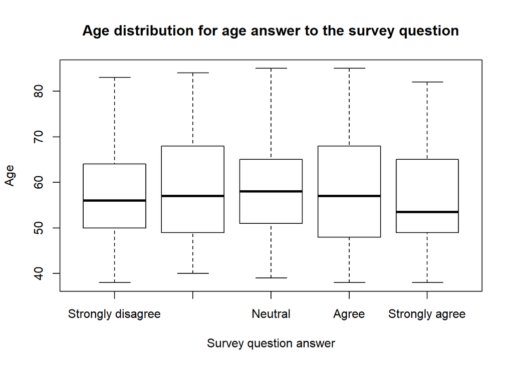

```r
boxplot(df$Age ~ df$Survey,
        main = "Age distribution for age answer to the survey question",
        xlab = "Survey question answer",
        ylab = "Age")
```

## Conclusion

The comparisons of means are some of the most commonly used statistical tests. While they are easy to implement, we will see in the next chapter, that they are based on a number of assumptions which must be investigated before they are used.